# Text Mining – Hands-on

v-1.2.0

Dott.ssa Ileana Baldi – Dott. Corrado Lanera

# Outline

- Preamble
  - strategy
  - packages
- Execution
  - Loading
  - Preprocess
  - Analyses
  - Visualization
- Links

# Preamble

In this Hands-on we will analyze a set of bibliographic citations downloaded from PubMed https://www.ncbi.nlm.nih.gov/pubmed. Our aim will be to extract some (sample) information to have the possibility to inspect each step of the text analysis process: retrieval, cleaning, transform, analyze.

We are interested to analyze all the paper published on PubMed related to the field of Machine Leaning in the last ten years. So go to the website, perform the following search:

```
("machine learning") AND ("2007/01/01"[Date - Publication] : "2017/01/01"[Date - Publication])
```

At February, 8th 2017 the search returned 9872 papers. Once we have the results, we can download them in the format we prefer, today we choose for the standard one: a Comma-Separated Value (`pubmed_result.csv`).

It is a good idea to start to inspect it with a simple text-editor to have a first look at the possible issues.

At the firs look, I see only the presence of iterative header every 50 rows more or less.

## Strategy

- (simulate the) data download
- setup R with the useful packages
- Loading
  - importing data
  - create a *corpus*
- preprocess
  - lowering
  - stopwords
  - punctuation
  - numbers
  - whitespace
  - stemming
  - 2-Gram
  - DTM creation (lengths, bounds, weights)
- analyses
  - Frequencies
  - Association
- Visualization
  - barplot
  - wordcloud
  - network

## Packages

There are some useful package I would like to introduce you, form the general ones for data manipulation, to the ones more specifically focused on text manipulation and management.

### Other

```r
if (!requireNamespace('wordcloud', quietly = TRUE)) {
    install.packages('wordcloud', dependencies = TRUE)
}
# Create word clouds
library('wordcloud', quietly = TRUE)
citation('wordcloud')
```

```
  Ian Fellows (2018). wordcloud: Word Clouds. R package version
  2.6. https://CRAN.R-project.org/package=wordcloud

A BibTeX entry for LaTeX users is

  @Manual{,
    title = {wordcloud: Word Clouds},
    author = {Ian Fellows},
    year = {2018},
    note = {R package version 2.6},
    url = {https://CRAN.R-project.org/package=wordcloud},
  }

ATTENTION: This citation information has been auto-generated from
the package DESCRIPTION file and may need manual editing, see
‘help("citation")’.
```

```r
#  -------
if (!requireNamespace('igraph', quietly = TRUE)) {
    install.packages('igraph', dependencies = TRUE)
}
# Simple graphs and network analysis
library('igraph', quietly = TRUE)
citation('igraph')
```

```
  Csardi G, Nepusz T: The igraph software package for complex
  network research, InterJournal, Complex Systems 1695. 2006.
  http://igraph.org

A BibTeX entry for LaTeX users is

  @Article{,
    title = {The igraph software package for complex network research},
    author = {Gabor Csardi and Tamas Nepusz},
    journal = {InterJournal},
    volume = {Complex Systems},
    pages = {1695},
    year = {2006},
    url = {http://igraph.org},
  }
```

### String manipulation

```r
if (!requireNamespace('stringr', quietly = TRUE)) {
    install.packages('stringr', dependencies = TRUE)
}
# A consistent, simple and easy to use set of wrappers around the
# fantastic 'stringi' package
library('stringr', quietly = TRUE)
citation('stringr')
```

```
  Hadley Wickham (2018). stringr: Simple, Consistent Wrappers for
  Common String Operations. R package version 1.3.1.
  https://CRAN.R-project.org/package=stringr

A BibTeX entry for LaTeX users is

  @Manual{,
    title = {stringr: Simple, Consistent Wrappers for Common String Operations},
    author = {Hadley Wickham},
    year = {2018},
    note = {R package version 1.3.1},
    url = {https://CRAN.R-project.org/package=stringr},
  }
```

### Text Manipulation

```r
if (!requireNamespace('tm', quietly = TRUE)) {
    install.packages('tm', dependencies = TRUE)
}
# Text Mining Package... the main focus of this hands-on
library('tm', quietly = TRUE)
citation('tm')
```

```
  Ingo Feinerer and Kurt Hornik (2018). tm: Text Mining Package. R
  package version 0.7-6. https://CRAN.R-project.org/package=tm

  Ingo Feinerer, Kurt Hornik, and David Meyer (2008). Text Mining
  Infrastructure in R. Journal of Statistical Software 25(5): 1-54.
  URL: http://www.jstatsoft.org/v25/i05/.

To see these entries in BibTeX format, use 'print(<citation>,
bibtex=TRUE)', 'toBibtex(.)', or set
'options(citation.bibtex.max=999)'.
```

### Data management (a single package bring-it-all)

```r
if (!requireNamespace('tidyverse', quietly = TRUE)) {
    install.packages('tidyverse', dependencies = TRUE)
}
# Easily Install and Load 'Tidyverse' Packages...
# ...they share common data representations and 'API' design.
library('tidyverse', quietly = TRUE)
# ggplot2: grammar of graphics
# tibble : trimmed down version of data.frame
# tidyr  : Easily Tidy Data with 'spread()' and 'gather()' Functions
# readr  : Read flat/tabular text files from disk (or a connection)
# purrr  : Functional Programming Tools
# dplyr  : A fast, consistent tool for working with data frame like objects,
#          both in memory and out of memory
citation('tidyverse')
```

```
  Hadley Wickham (2017). tidyverse: Easily Install and Load the
  'Tidyverse'. R package version 1.2.1.
  https://CRAN.R-project.org/package=tidyverse

A BibTeX entry for LaTeX users is

  @Manual{,
    title = {tidyverse: Easily Install and Load the 'Tidyverse'},
    author = {Hadley Wickham},
    year = {2017},
    note = {R package version 1.2.1},
    url = {https://CRAN.R-project.org/package=tidyverse},
  }
```

```r
# NOTE   : the tidyverse packages import the _pipe_ operator (%>%) from
#          the package `magrittr`. This little and simple operator is maybe
#          the most amazing tool you can learn to use. Its simplest works is
#          to let you avoid to write `f(x, y)` in favour of `x %>% f(y)`.
#          (Take a look at <http://r4ds.had.co.nz/pipes.html>)
```

# Execution

## Loading

### import

Start importing pubmed_result.csv into the workspace.

```r
original_file <- file.path(getwd(), 'pubmed_result.csv')
data <- read_csv(original_file)
```

```
9872 parsing failures.
row col   expected     actual                                                                                      file
  1  -- 11 columns 12 columns 'C:/Users/corra/ownCloud/Master_MLT/mlrpcc/vignettes/IB_w3/review-2019/pubmed_result.csv'
  2  -- 11 columns 12 columns 'C:/Users/corra/ownCloud/Master_MLT/mlrpcc/vignettes/IB_w3/review-2019/pubmed_result.csv'
  3  -- 11 columns 12 columns 'C:/Users/corra/ownCloud/Master_MLT/mlrpcc/vignettes/IB_w3/review-2019/pubmed_result.csv'
  4  -- 11 columns 12 columns 'C:/Users/corra/ownCloud/Master_MLT/mlrpcc/vignettes/IB_w3/review-2019/pubmed_result.csv'
  5  -- 11 columns 12 columns 'C:/Users/corra/ownCloud/Master_MLT/mlrpcc/vignettes/IB_w3/review-2019/pubmed_result.csv'
... ... .......... .......... .........................................................................................
See problems(...) for more details.
```

```r
## standard alternative
#
# data <- read.csv(
#     file            = original_file,
#     stringsAsFactor = FALSE,
#     header          = TRUE
#    )
```

There are some problems with the columns (i.e. separators), it seams that the data have one column more than the expected ones (i.e. number of headers). Take a look at it

```r
bad_text <- read_lines(original_file)
head(bad_text)
```

```
[1] "Title,URL,Description,Details,ShortDetails,Resource,Type,Identifiers,Db,EntrezUID,Properties"
[2] "\"PCA-based polling strategy in machine learning framework for coronary artery disease risk assessment in intravascular ultrasound: A link between carotid and coronary grayscale plaque morphology.\",\"/pubmed/27040838\",\"Araki T, Ikeda N, Shukla D, Jain PK, Londhe ND, Shrivastava VK, Banchhor …
[3] "\"Machine-learning identifies substance-specific behavioral markers for opiate and stimulant dependence.\",\"/pubmed/26905209\",\"Ahn WY, Vassileva J.\",\"Drug Alcohol Depend. 2016 Apr 1;161:247-57. doi: 10.1016/j.drugalcdep.2016.02.008.\",\"Drug Alcohol Depend.  2016\",\"PubMed\",\"citation\",…
[4] "\"Machine learning models in breast cancer survival prediction.\",\"/pubmed/26409558\",\"Montazeri M, Montazeri M, Montazeri M, Beigzadeh A.\",\"Technol Health Care. 2016;24(1):31-42. doi: 10.3233/THC-151071.\",\"Technol Health Care.  2016\",\"PubMed\",\"citation\",\"PMID:26409558\",\"pubmed\",…
[5] "\"Identification of novel Xanthomonas euvesicatoria type III effector proteins by a machine-learning approach.\",\"/pubmed/26104875\",\"Teper D, Burstein D, Salomon D, Gershovitz M, Pupko T, Sessa G.\",\"Mol Plant Pathol. 2016 Apr;17(3):398-411. doi: 10.1111/mpp.12288.\",\"Mol Plant Pathol.  20…
[6] "\"Systematic Poisoning Attacks on and Defenses for Machine Learning in Healthcare.\",\"/pubmed/25095272\",\"Mozaffari-Kermani M, Sur-Kolay S, Raghunathan A, Jha NK.\",\"IEEE J Biomed Health Inform. 2015 Nov;19(6):1893-905. doi: 10.1109/JBHI.2014.2344095.\",\"IEEE J Biomed Health Inform.  2015\"…
```

As expected there is a final extra “comma” at the end of each line.

Take now a look at the number of document (remember that we have retrieved 9872 document but we expect some fake row made of extra headers)

```r
length(bad_text)
```

```
[1] 10070
```

Lets clean the file, first of all we have to remove all the header but the first (remember that the header have no problem with the ending commas). So we can remove all the headers, remove all the ending commas, reinsert the header at the top (i.e. in the first position), merge all the element in a single one textual file dividing the lines with a “new line” character (i.e. `\n`) and finish the process by creating a data frame with all the data.

(As alternative, you can write the corrected character vector as a csv file into the hard-disk and next read it as before.)

Note: to clarify the use of the dot (“.”) with pipe read the corresponding (`?magrittr::\`%>%``) documentation.

```r
header <- bad_text[[1]]
good_data <- bad_text %>%
    .[. != header] %>%                               # remove al the header rows
    str_replace_all(pattern = ",$", replacement = '') %>% # remove ending commas
    c(header, .) %>%                                  # reinsert the main header
    str_c(collapse = '\n') %>%            # create a single csv-like text vector
    read_csv()                                       # read it into a data frame
good_data
```

| Title | URL | Description | Details | ShortDetails | Resource | Type | Identifiers | Db | EntrezUID | Properties |
| --- | --- | --- | --- | --- | --- | --- | --- | --- | --- | --- |
| PCA-based polling strategy in machine learning framework for coronary artery disease risk assessment in intravascular ultrasound: A link between carotid and coronary grayscale plaque morphology. | /pubmed/27040838 | Araki T, Ikeda N, Shukla D, Jain PK, Londhe ND, Shrivastava VK, Banchhor SK, Saba L, Nicolaides A, Shafique S, Laird JR, Suri JS. | Comput Methods Programs Biomed. 2016 May;128:137-58. doi: 10.1016/j.cmpb.2016.02.004. | Comput Methods Programs Biomed. 2016 | PubMed | citation | PMID:27040838 | pubmed | 27040838 | create date:2016/04/05 \| first author:Araki T |
| Machine-learning identifies substance-specific behavioral markers for opiate and stimulant dependence. | /pubmed/26905209 | Ahn WY, Vassileva J. | Drug Alcohol Depend. 2016 Apr 1;161:247-57. doi: 10.1016/j.drugalcdep.2016.02.008. | Drug Alcohol Depend. 2016 | PubMed | citation | PMID:26905209 \| PMCID:PMC4955649 | pubmed | 26905209 | create date:2016/02/26 \| first author:Ahn WY |
| Machine learning models in breast cancer survival prediction. | /pubmed/26409558 | Montazeri M, Montazeri M, Montazeri M, Beigzadeh A. | Technol Health Care. 2016;24(1):31-42. doi: 10.3233/THC-151071. | Technol Health Care. 2016 | PubMed | citation | PMID:26409558 | pubmed | 26409558 | create date:2015/09/28 \| first author:Montazeri M |
| Identification of novel Xanthomonas euvesicatoria type III effector proteins by a machine-learning approach. | /pubmed/26104875 | Teper D, Burstein D, Salomon D, Gershovitz M, Pupko T, Sessa G. | Mol Plant Pathol. 2016 Apr;17(3):398-411. doi: 10.1111/mpp.12288. | Mol Plant Pathol. 2016 | PubMed | citation | PMID:26104875 | pubmed | 26104875 | create date:2015/06/25 \| first author:Teper D |
| Systematic Poisoning Attacks on and Defenses for Machine Learning in Healthcare. | /pubmed/25095272 | Mozaffari-Kermani M, Sur-Kolay S, Raghunathan A, Jha NK. | IEEE J Biomed Health Inform. 2015 Nov;19(6):1893-905. doi: 10.1109/JBHI.2014.2344095. | IEEE J Biomed Health Inform. 2015 | PubMed | citation | PMID:25095272 | pubmed | 25095272 | create date:2014/08/06 \| first author:Mozaffari-Kermani M |
| [Fragments Woven into a Whole: A New Approach to the Diagnosis of Cancer through Mass Spectrometry and Machine-Learning]. | /pubmed/26731898 | Takeda S, Yoshimura K, Tanabe K. | Rinsho Byori. 2015 Sep;63(9):1083-9. Review. Japanese. | Rinsho Byori. 2015 | PubMed | citation | PMID:26731898 | pubmed | 26731898 | create date:2016/01/07 \| first author:Takeda S |
| Machine Learning methods for Quantitative Radiomic Biomarkers. | /pubmed/26278466 | Parmar C, Grossmann P, Bussink J, Lambin P, Aerts HJ. | Sci Rep. 2015 Aug 17;5:13087. doi: 10.1038/srep13087. | Sci Rep. 2015 | PubMed | citation | PMID:26278466 \| PMCID:PMC4538374 | pubmed | 26278466 | create date:2015/08/19 \| first author:Parmar C |
| Mortality risk prediction in burn injury: Comparison of logistic regression with machine learning approaches. | /pubmed/25931158 | Stylianou N, Akbarov A, Kontopantelis E, Buchan I, Dunn KW. | Burns. 2015 Aug;41(5):925-34. doi: 10.1016/j.burns.2015.03.016. | Burns. 2015 | PubMed | citation | PMID:25931158 | pubmed | 25931158 | create date:2015/05/02 \| first author:Stylianou N |
| Harnessing information from injury narratives in the 'big data' era: understanding and applying machine learning for injury surveillance. | /pubmed/26728004 | Vallmuur K, Marucci-Wellman HR, Taylor JA, Lehto M, Corns HL, Smith GS. | Inj Prev. 2016 Apr;22 Suppl 1:i34-42. doi: 10.1136/injuryprev-2015-041813. | Inj Prev. 2016 | PubMed | citation | PMID:26728004 \| PMCID:PMC4852152 | pubmed | 26728004 | create date:2016/01/06 \| first author:Vallmuur K |
| Application of Machine Learning in Postural Control Kinematics for the Diagnosis of Alzheimer's Disease. | /pubmed/28074090 | Costa L, Gago MF, Yelshyna D, Ferreira J, David Silva H, Rocha L, Sousa N, Bicho E. | Comput Intell Neurosci. 2016;2016:3891253. doi: 10.1155/2016/3891253. | Comput Intell Neurosci. 2016 | PubMed | citation | PMID:28074090 \| PMCID:PMC5203925 | pubmed | 28074090 | create date:2017/01/12 \| first author:Costa L |

[output cut: 990 more lines]

9872 elements as expected, no error, and no factor variables.

### corpus

To create the corpus of our document we have to retain only the `Title`. Next, as it is said into the documentation of `tm::VCorpus` (`?VCorpus`) we have to provide to this function a “Source” object (our object is a data frame, so take a look at `?DataframeSource`). As we can see we need a first column named “`doc_id`” which contains a unique string identifier for each document, and a second column named “`text`” which must contains a UTF-8 encoded string representing the document content. Wecan use the url as the unique identifier.

Once create it we can produce our corpus.

```r
# ?DataframeSource
# ?VCorpus
corpus <- good_data %>%
    dplyr::select(URL, Title) %>%
    dplyr::rename(doc_id = URL, text = Title) %>%
    DataframeSource() %>%
    VCorpus()
names(corpus) <- good_data$URL
corpus
```

```
<<VCorpus>>
Metadata:  corpus specific: 0, document level (indexed): 0
Content:  documents: 9872
```

To access to individual documents use `inspect()`.

```r
set.seed(1234567890)
watch <-  sample(length(corpus), 5)
inspect(corpus[watch])
```

```
<<VCorpus>>
Metadata:  corpus specific: 0, document level (indexed): 0
Content:  documents: 5

[[1]]
<<PlainTextDocument>>
Metadata:  7
Content:  chars: 95

[[2]]
<<PlainTextDocument>>
Metadata:  7
Content:  chars: 106

[[3]]
<<PlainTextDocument>>
Metadata:  7
Content:  chars: 104

[[4]]
<<PlainTextDocument>>
Metadata:  7
Content:  chars: 127

[[5]]
<<PlainTextDocument>>
Metadata:  7
Content:  chars: 73
```

Seven metadata each and a content each document. Take a look at them.

```r
# classical
str(corpus[[1]])
```

```
List of 2
 $ content: chr "PCA-based polling strategy in machine learning framework for coronary artery disease risk assessment in intrava"| __truncated__
 $ meta   :List of 7
  ..$ author       : chr(0)
  ..$ datetimestamp: POSIXlt[1:1], format: "2019-01-06 11:47:09"
  ..$ description  : chr(0)
  ..$ heading      : chr(0)
  ..$ id           : chr "/pubmed/27040838"
  ..$ language     : chr "en"
  ..$ origin       : chr(0)
  ..- attr(*, "class")= chr "TextDocumentMeta"
 - attr(*, "class")= chr [1:2] "PlainTextDocument" "TextDocument"
```

```r
# specific
content(corpus[[1]])
```

```
[1] "PCA-based polling strategy in machine learning framework for coronary artery disease risk assessment in intravascular ultrasound: A link between carotid and coronary grayscale plaque morphology."
```

```r
meta(corpus[[1]])
```

```
  author       : character(0)
  datetimestamp: 2019-01-06 11:47:09
  description  : character(0)
  heading      : character(0)
  id           : /pubmed/27040838
  language     : en
  origin       : character(0)
```

```r
meta(corpus[[1]], 'author')
```

```
character(0)
```

```r
# tm:::meta.PlainTextDocument
# tm:::content.PlainTextDocument
# tm:::inspect.VCorpus
```

Lets set some meta data at document level. To do this we can access at the structure of the corpus

```r
names(good_data)
```

```
 [1] "Title"        "URL"          "Description"  "Details"
 [5] "ShortDetails" "Resource"     "Type"         "Identifiers"
 [9] "Db"           "EntrezUID"    "Properties"
```

```r
# behind the scene a VCorps is a list of 3 element (take a look at what is
# returned by the function `VCorpus()` (run `VCorpus` and look at the last
# line), and what it is: run `tm:::as.VCorpus.list`). So, we want to modify its
# `content`. map2 scan two list in parallel (`.x` and `.y`) applying the defined
# function (at the right of the `~`) to each corresponding couple of elements.
# The content of a VCorpus is a list of document, and each one of them is a
# list of two: its content and its meta (take a look at `DataframeSource`
# which call `SimpleSource()` to define the reader which, by default, is
# `readPlain` which call `PlainTextDocument()` returning that list). So,
# we want to modify an element ("author") of the meta of each document.
# At the end, we have to return the modified element (the document with
# the updated "author" meta).
corpus$content <- map2(.x = content(corpus), .y = good_data$Description,
        ~ {
            .x$meta[['author']] <- .y
            .x
          }
)
map(watch, ~ content(corpus[[.]]))
```

```
[[1]]
[1] "Hedged predictions for traditional Chinese chronic gastritis diagnosis with confidence machine."

[[2]]
[1] "Boosting multiclass learning with repeating codes and weak detectors for protein subcellular localization."

[[3]]
[1] "Genome annotation test with validation on transcription start site and ChIP-Seq for Pol-II binding data."

[[4]]
[1] "Customized Prediction of Short Length of Stay Following Elective Cardiac Surgery in Elderly Patients Using a Genetic Algorithm."

[[5]]
[1] "Modeling Pathological Speech Perception From Data With Similarity Labels."
```

```r
map(watch, ~ meta(corpus[[.]]))
```

```
[[1]]
  author       : Wang H, Lin C, Yang F, Hu X.
  datetimestamp: 2019-01-06 11:47:10
  description  : character(0)
  heading      : character(0)
  id           : /pubmed/19386299
  language     : en
  origin       : character(0)

[[2]]
  author       : Lin CC, Tsai YS, Lin YS, Chiu TY, Hsiung CC, Lee MI, Simpson JC, Hsu CN.
  datetimestamp: 2019-01-06 11:47:10
  description  : character(0)
  heading      : character(0)
  id           : /pubmed/17956879
  language     : en
  origin       : character(0)

[[3]]
  author       : Bedo J, Kowalczyk A.
  datetimestamp: 2019-01-06 11:47:10
  description  : character(0)
  heading      : character(0)
  id           : /pubmed/21558156
  language     : en
  origin       : character(0)

[[4]]
  author       : Lee J, Govindan S, Celi LA, Khabbaz KR, Subramaniam B.
  datetimestamp: 2019-01-06 11:47:10
  description  : character(0)
  heading      : character(0)
  id           : /pubmed/24482754
  language     : en
  origin       : character(0)

[[5]]
  author       : Berisha V, Liss J, Sandoval S, Utianski R, Spanias A.
  datetimestamp: 2019-01-06 11:47:10
  description  : character(0)
  heading      : character(0)
  id           : /pubmed/25435817
  language     : en
  origin       : character(0)
```

## Preprocesing

Before to create the Document-Term Matrix (DTM) of our corpus, we need to perform on it some manipulation useful to assure the maximum meaningfulness of its content.

### Lowercase

The first step is to remember that R is case sensitive and if we want to analyze the words of several documents in terms of frequency or importance or any other characteristics of them, we have to be sure that every equal word is actually seen as equal. A common practice is to lowercase all the words of each document.

```r
map(watch, ~ content(corpus[[.]]))
```

```
[[1]]
[1] "Hedged predictions for traditional Chinese chronic gastritis diagnosis with confidence machine."

[[2]]
[1] "Boosting multiclass learning with repeating codes and weak detectors for protein subcellular localization."

[[3]]
[1] "Genome annotation test with validation on transcription start site and ChIP-Seq for Pol-II binding data."

[[4]]
[1] "Customized Prediction of Short Length of Stay Following Elective Cardiac Surgery in Elderly Patients Using a Genetic Algorithm."

[[5]]
[1] "Modeling Pathological Speech Perception From Data With Similarity Labels."
```

```r
corpus <- tm_map(
    x   = corpus,
    FUN = content_transformer(tolower)
)
map(watch, ~ content(corpus[[.]]))
```

```
[[1]]
[1] "hedged predictions for traditional chinese chronic gastritis diagnosis with confidence machine."

[[2]]
[1] "boosting multiclass learning with repeating codes and weak detectors for protein subcellular localization."

[[3]]
[1] "genome annotation test with validation on transcription start site and chip-seq for pol-ii binding data."

[[4]]
[1] "customized prediction of short length of stay following elective cardiac surgery in elderly patients using a genetic algorithm."

[[5]]
[1] "modeling pathological speech perception from data with similarity labels."
```

### Removing stopwords

Not meaningful words (generally this means “very common” but its not true every time) shouldn’t be considered to avoid unwanted noise in our data.

```r
# stopwords('english')
corpus <- tm_map(corpus,
            removeWords, c(stopwords('english'),"approach","weak")
)
map(watch, ~ content(corpus[[.]]))
```

```
[[1]]
[1] "hedged predictions  traditional chinese chronic gastritis diagnosis  confidence machine."

[[2]]
[1] "boosting multiclass learning  repeating codes   detectors  protein subcellular localization."

[[3]]
[1] "genome annotation test  validation  transcription start site  chip-seq  pol-ii binding data."

[[4]]
[1] "customized prediction  short length  stay following elective cardiac surgery  elderly patients using  genetic algorithm."

[[5]]
[1] "modeling pathological speech perception  data  similarity labels."
```

### Removing punctuation

Punctuation are (often) a source of great noise and redundancy (commonly words are detected by programs by chunks of characters divided by white space, e.g. every last word of a sentence is considered different from its own, because it has a dot attached at the end).

```r
corpus <- tm_map(corpus, removePunctuation)
map(watch, ~ content(corpus[[.]]))
```

```
[[1]]
[1] "hedged predictions  traditional chinese chronic gastritis diagnosis  confidence machine"

[[2]]
[1] "boosting multiclass learning  repeating codes   detectors  protein subcellular localization"

[[3]]
[1] "genome annotation test  validation  transcription start site  chipseq  polii binding data"

[[4]]
[1] "customized prediction  short length  stay following elective cardiac surgery  elderly patients using  genetic algorithm"

[[5]]
[1] "modeling pathological speech perception  data  similarity labels"
```

### Removing numbers

Generally numbers are not considered in basic text analyses

```r
corpus <- tm_map(corpus, removeNumbers)
map(watch, ~ content(corpus[[.]]))
```

```
[[1]]
[1] "hedged predictions  traditional chinese chronic gastritis diagnosis  confidence machine"

[[2]]
[1] "boosting multiclass learning  repeating codes   detectors  protein subcellular localization"

[[3]]
[1] "genome annotation test  validation  transcription start site  chipseq  polii binding data"

[[4]]
[1] "customized prediction  short length  stay following elective cardiac surgery  elderly patients using  genetic algorithm"

[[5]]
[1] "modeling pathological speech perception  data  similarity labels"
```

### Removing whitespace

All the “elimination” performed until now have left a great amount of redundant white spaces.

```r
corpus <- tm_map(corpus, stripWhitespace)
map(watch, ~ content(corpus[[.]]))
```

```
[[1]]
[1] "hedged predictions traditional chinese chronic gastritis diagnosis confidence machine"

[[2]]
[1] "boosting multiclass learning repeating codes detectors protein subcellular localization"

[[3]]
[1] "genome annotation test validation transcription start site chipseq polii binding data"

[[4]]
[1] "customized prediction short length stay following elective cardiac surgery elderly patients using genetic algorithm"

[[5]]
[1] "modeling pathological speech perception data similarity labels"
```

### Stemming

To merge more than a word into a single token we can perform a stemming of the words, passing to a not elementary human-readable bag of words, but now it contains tokens representing “concept”. (Consider to use lemmatization too. A not-so-simple to install program but well documented and quite easy-to-use to perform lemmatization is TreeTagger, interfaced in R by the `koRpus` package and its function `treetag()`.)

```r
corpus <- tm_map(corpus, stemDocument)
map(watch, ~ content(corpus[[.]]))
```

```
[[1]]
[1] "hedg predict tradit chines chronic gastriti diagnosi confid machin"

[[2]]
[1] "boost multiclass learn repeat code detector protein subcellular local"

[[3]]
[1] "genom annot test valid transcript start site chipseq polii bind data"

[[4]]
[1] "custom predict short length stay follow elect cardiac surgeri elder patient use genet algorithm"

[[5]]
[1] "model patholog speech percept data similar label"
```

> NOTE: `stemDocument()` (`?stemDocument`) is not the only stemmer, take a look at `SnowballC` too (`citation('SnowballC')`, after installing).

### Building 2-grams

Until now we had modified or deleted words to reduce the amount of token while increasing the amount of (useful) information retained by each one. Now we start to do the opposite: some information are impossible to retain in single words (i.g. negations), so it can be useful to consider token that are “sequence” of n words consecutively , i.e. nGram. This step introduce a huge amount of redundancy and possible noise and for this main reason it is not suggested to use n > 3 (and even n = 3 is proved to introduce more noise than the amount of information usable).

```r
BigramTokenizer <- function(x) {
        words(x) %>%
        ngrams(2) %>%
        map_chr(~ str_c(., collapse = ' '))
# NOTE: standard R
#    unlist(
#        lapply(ngrams(words(x), 2), paste, collapse = " "),
#        use.names = FALSE
#    )
}
# we whant to retain the unigramm too on the side of the bigram!!
UniBigramTokenizer <- function(x){
    c(words(x), BigramTokenizer(x))
}
#---------------
# check and test
# --------------
'today an hands-on about text mining' %>%
    VectorSource %>%
    VCorpus %>%
    .[[1]] %>%
    BigramTokenizer
```

```
[1] "today an"       "an hands-on"    "hands-on about" "about text"
[5] "text mining"
```

```r
'today an hands-on about text mining' %>%
    VectorSource %>%
    VCorpus %>%
    .[[1]] %>%
    UniBigramTokenizer
```

```
 [1] "today"          "an"             "hands-on"       "about"
 [5] "text"           "mining"         "today an"       "an hands-on"
 [9] "hands-on about" "about text"     "text mining"
```

### DTM

We are now ready to create our DTM. the tm package provide some more possibility of manipulation, as the selection of bounds for the number of characters that are considered for a token to be considered, as well as the number of document it has to be present.

```r
dtm <- DocumentTermMatrix(corpus,
    control = list(
        wordLengths = c(4, Inf),
        # bounds      = list(global = c(1, Inf)),
        weighting   = function(x) weightTfIdf(x, normalize = TRUE),
        tokenize    = UniBigramTokenizer
    )
)
dtm
```

```
<<DocumentTermMatrix (documents: 9872, terms: 61735)>>
Non-/sparse entries: 162347/609285573
Sparsity           : 100%
Maximal term length: 53
Weighting          : term frequency - inverse document frequency (normalized) (tf-idf)
```

```r
inspect(dtm[watch, 1:10])
```

```
<<DocumentTermMatrix (documents: 5, terms: 10)>>
Non-/sparse entries: 0/50
Sparsity           : 100%
Maximal term length: 16
Weighting          : term frequency - inverse document frequency (normalized) (tf-idf)
Sample             :
                  Terms
Docs                      γturn        γturn predict        νsupport
  /pubmed/19386299            0                    0               0
  /pubmed/17956879            0                    0               0
  /pubmed/21558156            0                    0               0
  /pubmed/24482754            0                    0               0
  /pubmed/25435817            0                    0               0
                  Terms
Docs                      νsupport vector        νtwin        νtwin support
  /pubmed/19386299                      0            0                    0
  /pubmed/17956879                      0            0                    0
  /pubmed/21558156                      0            0                    0
  /pubmed/24482754                      0            0                    0
  /pubmed/25435817                      0            0                    0
                  Terms
Docs                       learn         learn algorithm ≥ rectal
  /pubmed/19386299             0                       0        0
  /pubmed/17956879             0                       0        0
  /pubmed/21558156             0                       0        0
  /pubmed/24482754             0                       0        0
  /pubmed/25435817             0                       0        0
                  Terms
Docs               × crossvalid
  /pubmed/19386299            0
  /pubmed/17956879            0
  /pubmed/21558156            0
  /pubmed/24482754            0
  /pubmed/25435817            0
```

### Dimensions

#### Sizes (optional)

```r
dim(dtm)
```

```
[1]  9872 61735
```

```r
# Expected size (8 Byte each element for numbers, if they was all
# integers all stored `as.integer` it could be 4 Byte each one):
dim(dtm) %>%
    prod(8) %>%
    pryr:::print.bytes()
```

```
4.88 GB
```

```r
# Actual size:
pryr::object_size(dtm) # How is it possible???? Take a look of sparsity...
```

```
9.98 MB
```

```r
# NOTE: `pryr` is included in `tidyverse` but not directly loaded by it,
#        so we have to specify to R "were" to find the function we use
class(dtm)
```

```
[1] "DocumentTermMatrix"    "simple_triplet_matrix"
```

```r
str(dtm)
```

```
List of 6
 $ i       : int [1:162347] 1 1 1 1 1 1 1 1 1 1 ...
 $ j       : int [1:162347] 3499 3502 3667 3739 7827 7831 12371 12372 12378 16095 ...
 $ v       : Named num [1:162347] 0.223 0.269 0.145 0.359 0.262 ...
  ..- attr(*, "names")= chr [1:162347] "1" "1" "1" "1" ...
 $ nrow    : int 9872
 $ ncol    : int 61735
 $ dimnames:List of 2
  ..$ Docs : chr [1:9872] "/pubmed/27040838" "/pubmed/26905209" "/pubmed/26409558" "/pubmed/26104875" ...
  ..$ Terms: chr [1:61735] "γturn" "γturn predict" "νsupport" "νsupport vector" ...
 - attr(*, "class")= chr [1:2] "DocumentTermMatrix" "simple_triplet_matrix"
 - attr(*, "weighting")= chr [1:2] "term frequency - inverse document frequency (normalized)" "tf-idf"
```

```r
length(dtm$i) %>%
    prod(4) %>% # i, j, v, names
    sum(
        length(dtm$dimnames$Docs),
        length(dtm$dimnames$Terms)
    ) %>%
    prod(8) %>%
    pryr:::print.bytes()
```

```
5.77 MB
```

#### Quantity

We have obtained a very huge matrix difficult to manage and to use.

```r
dim(dtm)
```

```
[1]  9872 61735
```

```r
dim(removeSparseTerms(dtm, .2))
```

```
[1] 9872    0
```

```r
dim(removeSparseTerms(dtm, .97))
```

```
[1] 9872   36
```

```r
dim(removeSparseTerms(dtm, .99))
```

```
[1] 9872  145
```

```r
dim(removeSparseTerms(dtm, .999))
```

```
[1] 9872 1719
```

```r
dim(removeSparseTerms(dtm, .9993))
```

```
[1] 9872 2453
```

```r
dim(removeSparseTerms(dtm, .9996))
```

```
[1] 9872 4517
```

```r
dim(removeSparseTerms(dtm, .9999))
```

```
[1]  9872 61735
```

```r
#
dtm <- removeSparseTerms(dtm, .999)
dim(dtm)
```

```
[1] 9872 1719
```

## Analysis

We are now ready for the last part of the exercise: get some output.

### Frequencies

We call here frequencies , but remember we are using tf-idf weights and not frequencies! So everything from here referred as “frequency” it should be think as “importance”.

Find all the terms more with a weight grater than 100.

```r
frequent <- findFreqTerms(
    x        = dtm,
    lowfreq  = 100,
    highfreq = Inf
)
frequent
```

```
 [1] "algorithm"    "analysi"      "applic"       "base"
 [5] "cancer"       "classif"      "clinic"       "comput"
 [9] "data"         "detect"       "diseas"       "featur"
[13] "function"     "gene"         "identif"      "imag"
[17] "interact"     "learn"        "machin"       "machin learn"
[21] "method"       "model"        "network"      "predict"
[25] "protein"      "structur"     "system"
```

Look at the redundancy of the component of the bi-gram…

### Associations

Find the token most associated with the most weighted ones

```r
findAssocs(
    x        = dtm,
    terms    = frequent,
    corlimit = 0.1
)
```

```
$algorithm
       learn algorithm      classif algorithm        genet algorithm
                  0.49                   0.20                   0.20
machinelearn algorithm      algorithm predict         algorithm base
                  0.19                   0.15                   0.14

$analysi
     imag analysi      data analysi       analysi use   analysi predict
             0.27              0.24              0.19              0.15
   compon analysi    comput analysi discrimin analysi   network analysi
             0.15              0.15              0.14              0.14
   analysi machin    compar analysi     autom analysi            compon
             0.13              0.13              0.11              0.11
    genet analysi    integr analysi multivari analysi           princip
             0.10              0.10              0.10              0.10
   princip compon
             0.10

$applic
applic machin  learn applic
         0.29          0.29

$base
    learn base    base machin     model base   classif base algorithm base
          0.24           0.22           0.17           0.14           0.13
   method base   predict base  structur base    system base   base classif
          0.13           0.13           0.13           0.13           0.12

$cancer
  breast cancer          breast  prostat cancer     lung cancer
           0.50            0.42            0.29            0.25
        prostat   cancer surviv      cancer use cancer diagnosi
           0.23            0.19            0.18            0.17
 cancer patient colorect cancer            lung        prognosi
           0.17            0.17            0.16            0.16
       colorect  predict cancer     cancer cell          surviv
           0.14            0.14            0.13            0.12

$classif
      classif use   automat classif     classif model     learn classif
```

[output cut: 218 more lines]

```
              0.34               0.34               0.30               0.28
      use structur     learn structur  protein secondari    structur featur
              0.24               0.21               0.21               0.19
      structur mri   sequenc structur     structur model      structur base
              0.17               0.16               0.16               0.14
 structur function    classif protein         interactom
              0.12               0.11               0.11

$system
  system biolog  support system    dynam system    learn system
           0.29            0.25            0.21            0.19
     system use recognit system   expert system     system base
           0.18            0.17            0.16            0.15
  decis support          biolog          expert
           0.14            0.12            0.11
```

## Visualization

To draw plots it is useful to have an *ad hoc* structure. So, lets create a data frame with token and the relative weight, ordered from the greatest to the lowest.

```r
word_frequencies <- dtm %>%
    as.matrix %>%
    colSums %>%
    sort(decreasing = TRUE) %>%
    data_frame(
        word   = names(.),
        weight = .
    )
```

```
`data_frame()` is deprecated, use `tibble()`.
```

```r
word_frequencies
```

| word | weight |
| --- | --- |
| learn | 314.417913 |
| predict | 294.330076 |
| machin | 271.806911 |
| machin learn | 248.603653 |
| data | 202.895076 |
| model | 201.392565 |
| classif | 201.188308 |
| analysi | 176.007303 |
| protein | 162.076693 |
| network | 153.128054 |

[output cut: 990 more lines]

### Barplot

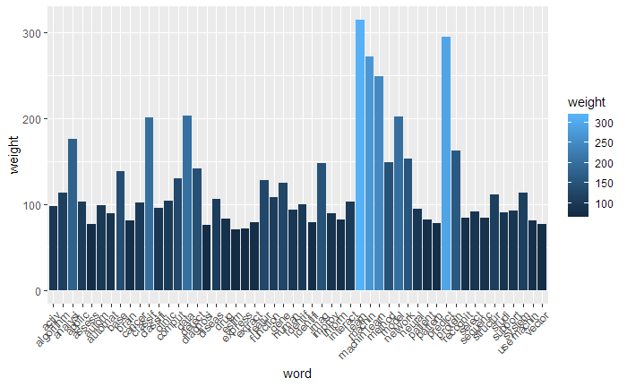

```r
word_frequencies %>%
    filter(weight > 70) %>%
    ggplot(aes(x = word, y = weight)) +
    geom_bar(stat = 'identity', aes(fill = weight)) +
    theme(
        axis.text.x = element_text(angle = 45, hjust = 1)
    )
ggsave('word_frequencies.pdf')
```

### Wordcloud

And finally, the word cloud.

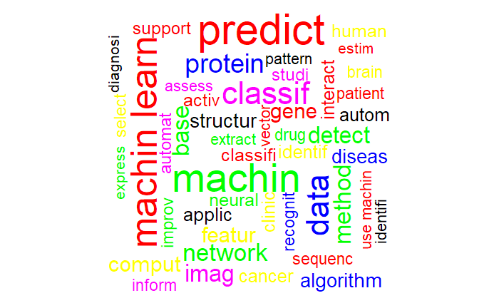

```r
wordcloud(
    words        = word_frequencies$word,
    freq         = word_frequencies$weight,
    min.freq     = 70,
    random.order = TRUE,
    rot.per      = .33,
    colors       = c('black', 'red', 'blue', 'yellow', 'green','magenta'),
    random.color = TRUE
)
```

### Network

Provided by `tm` there are a plot methods to draw the (weighted) correlation network of the (subset selected into the) dtm. It is based on a plot method provided by `Rgraphviz` which is no more into the CRAN. You can install it by the bioconductor:

```
source("http://bioconductor.org/biocLite.R")
    biocLite("Rgraphviz")
```

With default parameter is quite unuseful…

```
partial argument match of 'length' to 'length.out'partial argument match of 'length' to 'length.out'
```

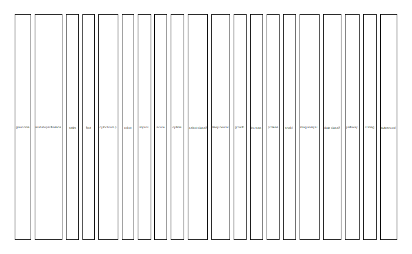

```r
plot(dtm #,
#     terms        = sample(Terms(x), 20),
#     corThreshold = 0.7,
#     weighting    = FALSE
)
```

But, you can easily obtain something more informative, like this

```
partial argument match of 'length' to 'length.out'partial argument match of 'length' to 'length.out'
```

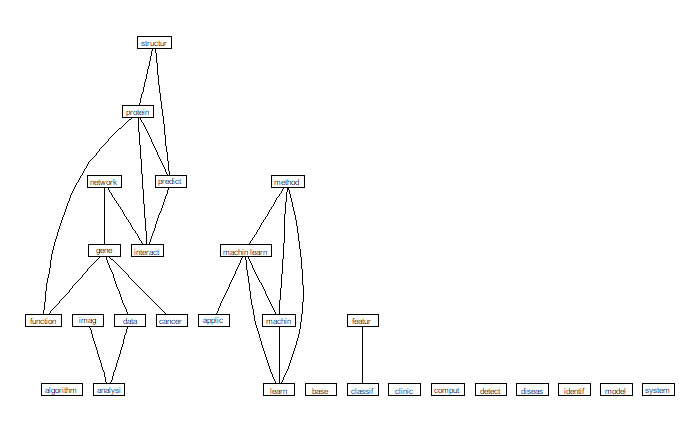

```r
# ?plot.TermDocumentMatrix
plot(dtm,
     terms        = findFreqTerms(dtm, lowfreq = 100),
     corThreshold = 0.05,        # Do not plot correlations below this threshold
     weighting    = FALSE    # whether line width corresponds to the correlation
)
```

Other possible way to draw a network

```r
 # bring a subset of interest
 dtm_reduced <- dtm[, findFreqTerms(dtm, lowfreq = 100)]
 termMatrix <- t(as.matrix(dtm_reduced)) %*% (as.matrix(dtm_reduced))
 # inspect terms numbered 5 to 10
 termMatrix[5:10,5:10]
```

```
         Terms
Terms         cancer   classif     clinic     comput      data     detect
  cancer  32.2364657  3.376308  0.7727217  1.2919795  2.846457  0.8491323
  classif  3.3763078 49.289710  1.9737291  1.0193752  5.398766  1.3371734
  clinic   0.7727217  1.973729 33.7249486  0.6028492  2.854720  0.9676666
  comput   1.2919795  1.019375  0.6028492 52.4424709  1.279793  1.1474184
  data     2.8464572  5.398766  2.8547205  1.2797933 51.223702  1.5219479
  detect   0.8491323  1.337173  0.9676666  1.1474184  1.521948 42.2369623
```

```
partial argument match of 'length' to 'length.out'partial argument match of 'frame' to 'frame.plot'
```

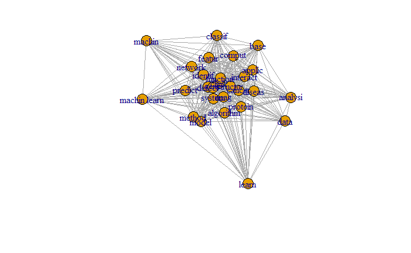

```r
 # build a graph from the above matrix, removing loops
 g <- graph.adjacency(termMatrix, weighted = TRUE, mode = "undirected") %>%
     igraph::simplify() # purrr and igraph share the same name for function

 # set labels and degrees of vertices (take a look at `?V`)
 V(g)$label  <- V(g)$name
 V(g)$degree <- degree(g)
 # plot the results your preferred layout
 plot(g, layout = layout.kamada.kawai)
```

```
partial argument match of 'length' to 'length.out'partial argument match of 'frame' to 'frame.plot'
```

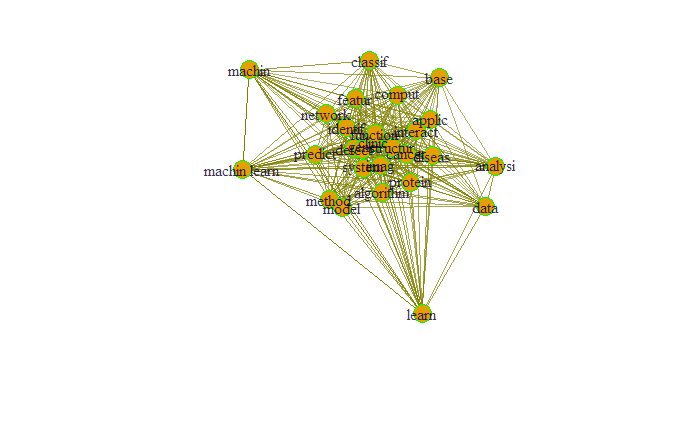

```r
# tkplot(g, layout = layout.kamada.kawai)
 # other options can be customized
 V(g)$label.color <- rgb(0, 0, .2, .8)
 V(g)$frame.color <- 'green'

 egam <- (((log(E(g)$weight) + .4) / max(log(E(g)$weight) + .4)) + 1)
 egam <- egam/max(egam)
 E(g)$color <- rgb(.5, .5, 0, egam)
 E(g)$width <- egam

 plot(g,   layout = layout.kamada.kawai)
```

```r
# tkplot(g, layout = layout.kamada.kawai)
```

# Links

- R help: `?`
- tm manual: https://cran.r-project.org/web/packages/tm/vignettes/tm.pdf
- tm example: https://eight2late.wordpress.com/2015/05/27/a-gentle-introduction-to-text-mining-using-r/
- TF-iDF: http://www.r-bloggers.com/the-tf-idf-statistic-for-keyword-extraction/
- build a search engine:http://anythingbutrbitrary.blogspot.it/2013/03/build-search-engine-in-20-minutes-or.html
- ggplot2 tutorial: http://tutorials.iq.harvard.edu/R/Rgraphics/Rgraphics.html
- bioconductor: https://www.bioconductor.org